# Supplementary acoustic space plots

[Grace Smith-Vidaurre](https://smith-vidaurrelab.github.io/)<sup>1-3*</sup>, [Summer G. Eckhardt](https://smith-vidaurrelab.github.io/team/)<sup>1,3</sup> <sup>1</sup>Department of Integrative Biology, Michigan State University <sup>2</sup>Department of Computational Mathematics, Science, and Engineering, Michigan State University <sup>3</sup>Ecology, Evolution, and Behavior Program, Michigan State University *Corresponding author (smithvid@msu.edu)

21 August 2025

**Purpose**: Here we use build acoustic space plots for supplementary figures. Acoustic space plots are generated using multidimensional scaling coordinates from spectrographic cross-correlation and edit distance analyses.

The code in this script and the script to generate acoustic space plots for main figures should specify the same axis limits and breaks across plots for the same dataset and similarity method, but this needs to be checked carefully when assembling the final composite figures. Each composite figure should only have a single legend at the top of the file, and shared x- and y-axis dimensions.

This code creates a plot of calls from both datasets in the same universal acoustic space (edit distance or SPCC). This plot should have 4 panels when complied in Inkscape: datasets plotted with polygons at both social levels.

To generate a legend of the correct size for a composite figure, we write out one large image file for each composite figure that is sized correctly for the legend, then crop the figure to include the legend only in Inkscape.

Load packages and set paths.

```r
# Clean the global environment
rm(list = ls())

# Specify the required packages
X <- c("dplyr", "tidyverse", "pbapply", "paletteer")

# Install the packages in X if not already installed
is_installed <- function(p) is.element(p, installed.packages()[,1])

invisible(lapply(1:length(X), function(x){
  if(!is_installed(X[x])){
    install.packages(X[x], repos = "http://lib.stat.cmu.edu/R/CRAN")
  }
}))
```

```r
# Load all of the packages specified above
invisible(lapply(X, library, character.only = TRUE, verbose = FALSE))
```

Initialize working directories for data on your local machine.

```r
# Initialize a base path (this will need to be different per user)
# path <- "/Users/raneemsamman/Desktop" # Raneem's path
# path <- "/Users/gracesmith-vidaurre/Desktop" # Grace's path
path <- "/Users/gsvidaurre/Desktop" # Grace's path
# path <- "/Users/summe/OneDrive/Desktop" #Summer's path
# path <- "C:/Users/britt/Desktop" # Britt's path


# Initialize a path for the local GitHub repo for this manuscript, for saving final figures here
# git_path <- "C:/Users/britt/Documents/GitHub" # Britt's path
git_path <- file.path("/Users/gsvidaurre/Desktop/GitHub_repos") # Grace's path
# git_path <- file.path(path, "github_repo") # Summer's path

# Initialize the directory for analysis on your local computer
analysis_dir <- "paRsynth_methods_synthetic_dataset"

# Combine the base path and the data directory into a single path
analysis_path <- file.path(path, analysis_dir)

# Create the data directory if it doesn't already exist on your computer
if(!dir.exists(analysis_path)){
  dir.create(analysis_path)
}

# Specify a folder inside the analysis directory where images for figures will be written out/read in
figures_dir <- "figures"

# Combine the base path, the analysis directory, and the data directory into a single path
figures_path <- file.path(path, analysis_dir, figures_dir)

# Create the data directory if it doesn't already exist on your computer
if(!dir.exists(figures_path)){
  dir.create(figures_path)
}

# Specify a folder inside the analysis directory where images for figures will be written out/read in
figures_dir <- "paRsynth-methods-paper/figures/supplementary_figures"

# Combine the base path, the analysis directory, and the data directory into a single path
figures_path <- file.path(git_path, figures_dir)
```

Read in the synthetic call metadata, and MDS coordinates. Set cores for parallel processing.

```r
synthetic_call_metadata <- read.csv(file.path(analysis_path, "synthetic_call_metadata.csv"))
glimpse(synthetic_call_metadata)
```

```
## Rows: 500
## Columns: 24
## $ Group           <int> 1, 1, 1, 1, 1, 1, 1, 1, 1, 1, 1, 1, 1, 1, 1, 1, 1, 1, …
## $ Individual      <int> 1, 1, 1, 1, 1, 2, 2, 2, 2, 2, 3, 3, 3, 3, 3, 4, 4, 4, …
## $ Call_ID         <int> 1, 2, 3, 4, 5, 1, 2, 3, 4, 5, 1, 2, 3, 4, 5, 1, 2, 3, …
## $ Call            <chr> "CABCAABACCBCCBAA", "CABCAABACCBCCBAA", "CABCAABACBBCC…
## $ Parsons_Code    <chr> "constant-up-down-constant-up-up-down-up-constant-cons…
## $ Frequency1      <int> 4000, 4000, 4000, 4000, 4000, 4000, 4000, 4000, 4000, …
## $ Frequency2      <int> 4000, 4000, 4000, 4000, 4000, 4000, 4000, 4000, 4000, …
## $ Frequency3      <int> 5000, 5000, 5000, 5000, 5000, 5000, 5000, 5000, 5000, …
## $ Frequency4      <int> 4000, 4000, 4000, 4000, 4000, 4000, 4000, 4000, 4000, …
## $ Frequency5      <int> 4000, 4000, 4000, 4000, 4000, 4000, 4000, 4000, 4000, …
## $ Frequency6      <int> 5000, 5000, 5000, 5000, 5000, 5000, 5000, 5000, 5000, …
## $ Frequency7      <int> 6000, 6000, 6000, 6000, 6000, 6000, 6000, 6000, 6000, …
## $ Frequency8      <int> 3000, 3000, 3000, 3000, 3000, 4000, 4000, 4000, 4000, …
## $ Frequency9      <int> 4000, 4000, 4000, 4000, 4000, 4000, 4000, 4000, 4000, …
## $ Frequency10     <int> 4000, 4000, 4000, 3000, 5000, 5000, 4000, 4000, 5000, …
## $ Frequency11     <int> 4000, 4000, 3000, 2000, 4000, 4000, 3000, 5000, 6000, …
## $ Frequency12     <int> 3000, 3000, 3000, 3000, 3000, 3000, 3000, 3000, 3000, …
## $ Frequency13     <int> 3000, 3000, 3000, 3000, 3000, 3000, 3000, 3000, 3000, …
## $ Frequency14     <int> 4000, 4000, 4000, 4000, 4000, 4000, 4000, 4000, 4000, …
## $ Frequency15     <int> 3000, 3000, 3000, 3000, 3000, 3000, 3000, 3000, 3000, …
## $ Frequency16     <int> 4000, 4000, 4000, 4000, 4000, 4000, 4000, 4000, 4000, …
## $ Frequency17     <int> 5000, 5000, 5000, 5000, 5000, 5000, 5000, 5000, 5000, …
## $ audio_file_name <chr> "GroupMembership_Group1_Indiv1_Call1.wav", "GroupMembe…
## $ dataset         <chr> "Group_Membership", "Group_Membership", "Group_Members…
```

```r
mds_coords <- read.csv(file.path(analysis_path, "MDS_coordinates.csv"))
glimpse(mds_coords)
```

```
## Rows: 1,000
## Columns: 8
## $ sound.files        <chr> "GroupMembership_Group1_Indiv1_Call1.wav", "GroupMe…
## $ X                  <dbl> -0.2166648, -0.2203792, -0.2064050, -0.1786338, -0.…
## $ Y                  <dbl> -0.122519612, -0.120751577, -0.146505067, -0.208834…
## $ group_ID           <int> 1, 1, 1, 1, 1, 1, 1, 1, 1, 1, 1, 1, 1, 1, 1, 1, 1, …
## $ individual_ID      <int> 1, 1, 1, 1, 1, 10, 10, 10, 10, 10, 2, 2, 2, 2, 2, 3…
## $ dataset            <chr> "Group Membership", "Group Membership", "Group Memb…
## $ unique_individuals <chr> "1 - 1", "1 - 1", "1 - 1", "1 - 1", "1 - 1", "1 - 1…
## $ method             <chr> "SPCC", "SPCC", "SPCC", "SPCC", "SPCC", "SPCC", "SP…
```

```r
cores <- parallel::detectCores() - 4
cores
```

```
## [1] 4
```

## Step 1: Group-specific dataset

Start with aesthetics.

```r
# Get colors for groups from the same palette used for spectrograms in lexicons
cols <- paletteer::paletteer_d("nationalparkcolors::Arches")
cols
```

```
## <colors>
## #A8CDECFF #F6955EFF #682C37FF #9B6981FF #7887A4FF #A89F8EFF
```

```r
# Combine MDS results from the SPCC and edit distance pipelines
mds_spcc_grp <- mds_coords %>%
  # Filter by the group membership calls and MDS coordinates from SPCC
  dplyr::filter(
    dataset == "Group Membership", method == "SPCC"
  ) %>%
  # Convert strings to factors for plotting
  dplyr::mutate(
    group_ID = factor(group_ID),
    individual_ID = factor(individual_ID)
  )

glimpse(mds_spcc_grp)
```

```
## Rows: 250
## Columns: 8
## $ sound.files        <chr> "GroupMembership_Group1_Indiv1_Call1.wav", "GroupMe…
## $ X                  <dbl> -0.2166648, -0.2203792, -0.2064050, -0.1786338, -0.…
## $ Y                  <dbl> -0.122519612, -0.120751577, -0.146505067, -0.208834…
## $ group_ID           <fct> 1, 1, 1, 1, 1, 1, 1, 1, 1, 1, 1, 1, 1, 1, 1, 1, 1, …
## $ individual_ID      <fct> 1, 1, 1, 1, 1, 10, 10, 10, 10, 10, 2, 2, 2, 2, 2, 3…
## $ dataset            <chr> "Group Membership", "Group Membership", "Group Memb…
## $ unique_individuals <chr> "1 - 1", "1 - 1", "1 - 1", "1 - 1", "1 - 1", "1 - 1…
## $ method             <chr> "SPCC", "SPCC", "SPCC", "SPCC", "SPCC", "SPCC", "SP…
```

```r
mds_edit_grp <- mds_coords %>%
  # Filter by the group membership calls and MDS coordinates from SPCC
  dplyr::filter(
    dataset == "Group Membership", method == "edit"
  ) %>%
  dplyr::mutate(
    group_ID = factor(group_ID),
    individual_ID = factor(individual_ID)
  )

glimpse(mds_edit_grp)
```

```
## Rows: 250
## Columns: 8
## $ sound.files        <chr> "GroupMembership_Group1_Indiv1_Call1.wav", "GroupMe…
## $ X                  <dbl> -3.746273, -3.648048, -3.674134, -3.618295, -3.6572…
## $ Y                  <dbl> 0.25714939, 0.25303453, -0.52302028, -1.37163849, -…
## $ group_ID           <fct> 1, 1, 1, 1, 1, 1, 1, 1, 1, 1, 1, 1, 1, 1, 1, 1, 1, …
## $ individual_ID      <fct> 1, 1, 1, 1, 1, 10, 10, 10, 10, 10, 2, 2, 2, 2, 2, 3…
## $ dataset            <chr> "Group Membership", "Group Membership", "Group Memb…
## $ unique_individuals <chr> "1 - 1", "1 - 1", "1 - 1", "1 - 1", "1 - 1", "1 - 1…
## $ method             <chr> "edit", "edit", "edit", "edit", "edit", "edit", "ed…
```

```r
levels(mds_spcc_grp$group_ID)
```

```
## [1] "1" "2" "3" "4" "5"
```

```r
levels(mds_spcc_grp$individual_ID)
```

```
##  [1] "1"  "2"  "3"  "4"  "5"  "6"  "7"  "8"  "9"  "10"
```

```r
# Colors by group (five)
cols_grp <- cols[1:length(levels(mds_spcc_grp$group))]
cols_grp
```

```
## <colors>
## #A8CDECFF #F6955EFF #682C37FF #9B6981FF #7887A4FF
```

```r
# Fills by unique individual
fills <- rep(cols_grp, each = length(levels(mds_spcc_grp$individual_ID)))
length(fills)
```

```
## [1] 50
```

```r
unique(fills)
```

```
## [1] "#A8CDECFF" "#F6955EFF" "#682C37FF" "#9B6981FF" "#7887A4FF"
```

```r
# Shapes by individual within groups
shps <- c(7, 8, 10, 4, 16, 17, 21, 23, 24, 6)
```

## Step 1a: Group-level polygons

### Edit distance, group-specific dataset and group-level polygons

Create the group membership plots. Edit distance first with a legend.

```r
# Convex hull polygons per group
hulls <- plyr::ddply(mds_edit_grp, "group_ID", function(x){
  x[chull(x$X, x$Y), ]
})

glimpse(hulls)
```

```
## Rows: 48
## Columns: 8
## $ sound.files        <chr> "GroupMembership_Group1_Indiv4_Call1.wav", "GroupMe…
## $ X                  <dbl> -3.297086, -3.427385, -3.618295, -3.746209, -3.8616…
## $ Y                  <dbl> 0.07343359, -1.36473546, -1.37163849, -1.31809570, …
## $ group_ID           <fct> 1, 1, 1, 1, 1, 1, 1, 1, 1, 1, 1, 2, 2, 2, 2, 2, 2, …
## $ individual_ID      <fct> 4, 10, 1, 7, 7, 5, 5, 8, 3, 2, 4, 8, 9, 1, 1, 1, 3,…
## $ dataset            <chr> "Group Membership", "Group Membership", "Group Memb…
## $ unique_individuals <chr> "1 - 4", "1 - 10", "1 - 1", "1 - 7", "1 - 7", "1 - …
## $ method             <chr> "edit", "edit", "edit", "edit", "edit", "edit", "ed…
```

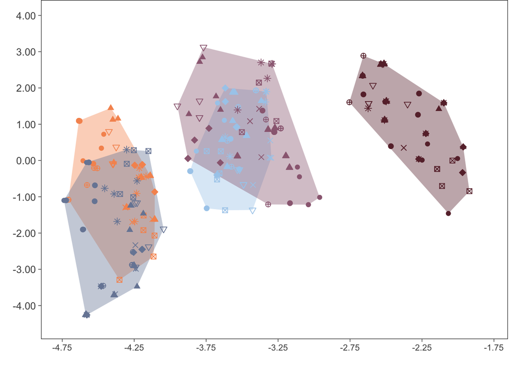

```r
mds_edit_grp %>%
  ggplot(aes(x = X, y = Y)) +
  geom_polygon(data = hulls, aes(x = X, y = Y, fill = group_ID), alpha = 0.4, linewidth = 0.2, show.legend = FALSE) +
  geom_point(aes(fill = group_ID, color = group_ID, shape = individual_ID), size = 2, stroke = 0.5) +
  scale_shape_manual(values = shps) +
  scale_color_manual(values = cols_grp) +
  scale_fill_manual(values = cols_grp) +
  xlab("") + ylab("") +
  guides(color = guide_legend(title = "Group", override.aes = list(size = 3), order = 1), shape = guide_legend(title = "Individual", nrow = 1), fill = guide_legend(title = "Group", order = 1)) +
  # Uncomment this line to turn off the legend
  guides(color = "none", shape = "none", fill = "none") +
  # Specify the x and y-axis limits and breaks. Make sure that each label retains two decimal places even when there is a trailing zero
  scale_x_continuous(limits = c(-4.75, -1.8), breaks = seq(-4.75, -1.75, 0.5), labels = sprintf("%.2f", round(seq(-4.75, -1.75, 0.5), 2))) +
  scale_y_continuous(limits = c(-4.5, 4), breaks = seq(-4, 4, 1), labels = sprintf("%.2f", round(seq(-4, 4, 1), 2))) +
  theme_bw() +
  theme(
    axis.title = element_text(size = 14),
    axis.text.x = element_text(size = 8.5),
    axis.text.y = element_text(size = 10),
    panel.grid.major = element_blank(),
    panel.grid.minor = element_blank(),
    axis.ticks = element_line(linewidth = 0.25),
    legend.position = "top",
    legend.key.spacing = unit(0.2, "lines"),
    legend.title = element_text(size = 10),
    legend.text = element_text(size = 10),
    # margin() arguments: top, right, bottom, left
    plot.margin = margin(0, 3, -3, -3, unit = "pt"),
    legend.margin = margin(2, -3, -5, -3, unit = "pt")
  )
```

```r
# Save this plot as an image file
# This image size (and font sizes or other aesthetics above) should be iteratively updated to fit a composite figure of multiple acoustic space plots created in other software
ggsave(filename = file.path(figures_path, "Fig_S1", "Suppl_AcousticSpace_edit_GroupMembership_GroupPolygons.tiff"), width = 3.535, height = 3.771, units = "in", dpi = 300)
```

### SPCC, group-specific dataset and group-level polygons

SPCC next with a legend.

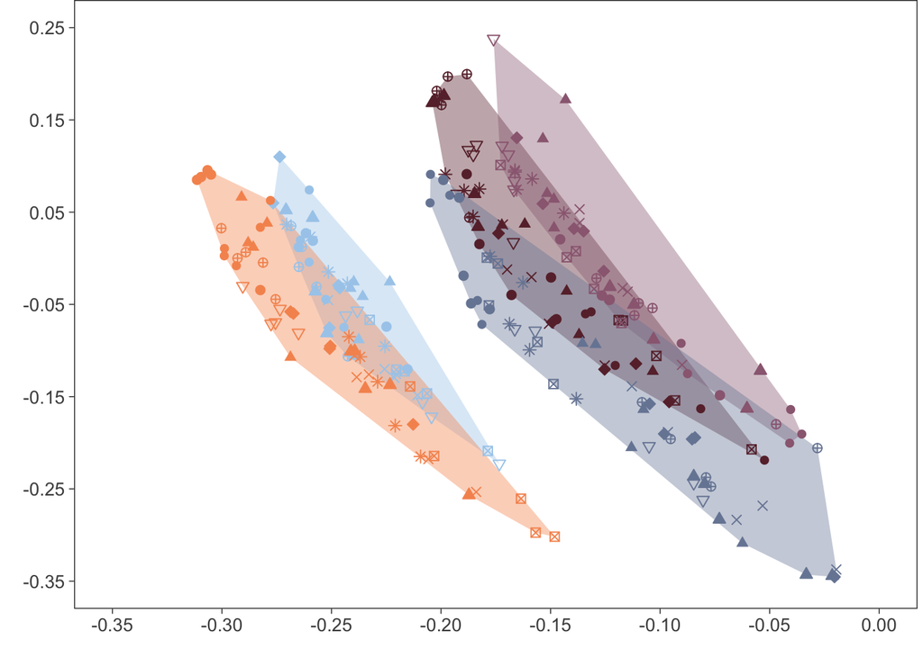

```r
# Convex hull polygons per group
hulls <- plyr::ddply(mds_spcc_grp, "group_ID", function(x){
  x[chull(x$X, x$Y), ]
})

# glimpse(hulls)

mds_spcc_grp %>%
  ggplot(aes(x = X, y = Y)) +
  geom_polygon(data = hulls, aes(x = X, y = Y, fill = group_ID), alpha = 0.4, linewidth = 0.2, show.legend = FALSE) +
  geom_point(aes(fill = group_ID, color = group_ID, shape = individual_ID), size = 2, stroke = 0.5) +
  scale_shape_manual(values = shps) +
  scale_color_manual(values = cols_grp) +
  scale_fill_manual(values = cols_grp) +
  xlab("") + ylab("") +
  guides(color = guide_legend(title = "Group", override.aes = list(size = 3), order = 1), shape = guide_legend(title = "Individual", nrow = 1), fill = guide_legend(title = "Group", order = 1)) +
  # Uncomment this line to turn off the legend
   guides(color = "none", shape = "none", fill = "none") +
  # Specify the x and y-axis limits and breaks. Make sure that each label retains two decimal places even when there is a trailing zero
  scale_x_continuous(limits = c(-0.35, 0), breaks = seq(-0.35, 0, 0.05), labels = sprintf("%.2f", round(seq(-0.35, 0, 0.05), 2))) +
  scale_y_continuous(limits = c(-0.35, 0.25), breaks = seq(-0.35, 0.25, 0.1), labels = sprintf("%.2f", round(seq(-0.35, 0.25, 0.1), 2))) +
  theme_bw() +
  theme(
    axis.title = element_text(size = 14),
    axis.text = element_text(size = 10),
    panel.grid.major = element_blank(),
    panel.grid.minor = element_blank(),
    axis.ticks = element_line(linewidth = 0.25),
    legend.position = "top",
    legend.key.spacing = unit(0.2, "lines"),
    legend.title = element_text(size = 10),
    legend.text = element_text(size = 10),
    # margin() arguments: top, right, bottom, left
    plot.margin = margin(0, 3, -3, -3, unit = "pt"),
    legend.margin = margin(2, -3, -5, -3, unit = "pt")
  )
```

```r
# Save this plot as an image file
# This image size (and font sizes or other aesthetics above) should be iteratively updated to fit a composite figure of multiple acoustic space plots created in other software
ggsave(filename = file.path(figures_path, "Fig_S2", "Suppl_AcousticSpace_SPCC_GroupMembership_GroupPolygons.tiff"), width = 3.535, height = 3.771, units = "in", dpi = 300)
```

## Step 1b: Individual-level polygons

### Edit distance, group-specific dataset and individual-level polygons

Edit distance first with a legend. Use the same continuous x and y-axis scales as the main figures.

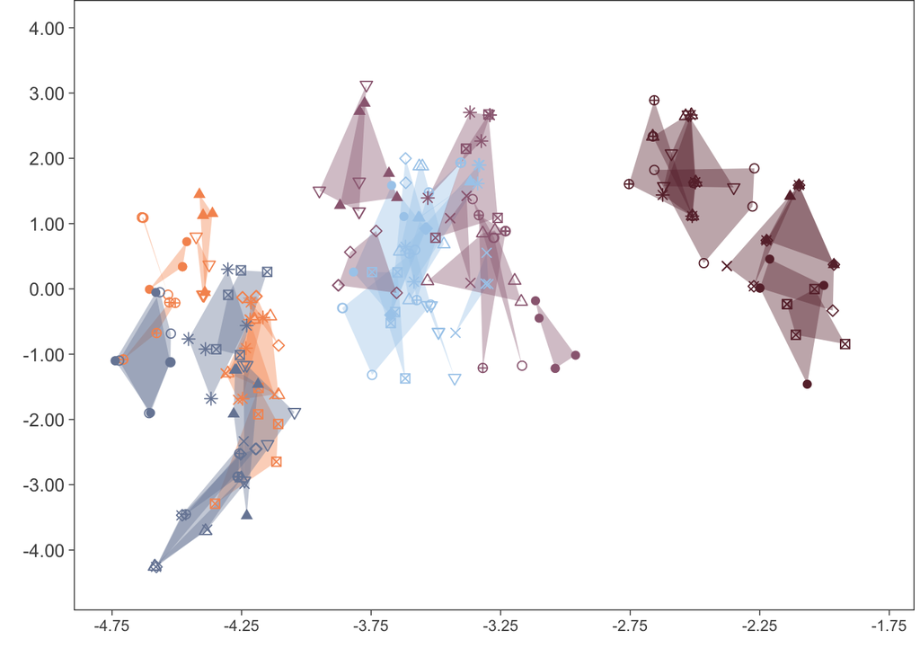

```r
# Convex hull polygons per group
hulls <- plyr::ddply(mds_edit_grp, "unique_individuals", function(x){
  x[chull(x$X, x$Y), ]
})

# glimpse(hulls)

mds_edit_grp %>%
  ggplot(aes(x = X, y = Y)) +
  geom_polygon(data = hulls, aes(x = X, y = Y, fill = unique_individuals), alpha = 0.4, linewidth = 0.2, show.legend = FALSE) +
  geom_point(aes(color = group_ID, shape = individual_ID), size = 2, stroke = 0.5) +
  scale_shape_manual(values = shps) +
  scale_color_manual(values = cols_grp) +
  scale_fill_manual(values = fills) +
  xlab("") + ylab("") +
  guides(color = guide_legend(title = "Group", override.aes = list(size = 3), order = 1), shape = guide_legend(title = "Individual", nrow = 1), fill = "none") +
  # Uncomment this line to turn off the legend
   guides(color = "none", shape = "none", fill = "none") +
  # Specify the x and y-axis limits so that these are the same across plots
  # Also make sure that each label retains two decimal places even when there is a trailing zero
  scale_x_continuous(limits = c(-4.75, -1.8), breaks = seq(-4.75, -1.75, 0.5), labels = sprintf("%.2f", round(seq(-4.75, -1.75, 0.5), 2))) +
  scale_y_continuous(limits = c(-4.5, 4), breaks = seq(-4, 4, 1), labels = sprintf("%.2f", round(seq(-4, 4, 1), 2))) +
  theme_bw() +
  theme(
    axis.title = element_text(size = 14),
    axis.text.x = element_text(size = 8.5),
    axis.text.y = element_text(size = 10),
    strip.text.x = element_text(size = 12),
    strip.text.y = element_text(size = 10),
    panel.grid.major = element_blank(),
    panel.grid.minor = element_blank(),
    axis.ticks = element_line(linewidth = 0.25),
    legend.position = "top",
    legend.key.spacing = unit(0.2, "lines"),
    # margin() arguments: top, right, bottom, left
    plot.margin = margin(0, 3, -3, -3, unit = "pt"),
    legend.margin = margin(2, -3, -5, -3, unit = "pt")
  )
```

```r
# Save this plot as an image file
# This image size (and font sizes or other aesthetics above) should be iteratively updated to fit a composite figure of multiple acoustic space plots created in other software
ggsave(filename = file.path(figures_path, "Fig_S1", "Suppl_AcousticSpace_edit_GroupMembership_IndividualPolygons.tiff"), width = 3.535, height = 3.771, units = "in", dpi = 300)
```

### SPCC, group membership dataset and individual-level polygons

SPCC with a legend. Use the same continuous x and y-axis scales as the main figures.

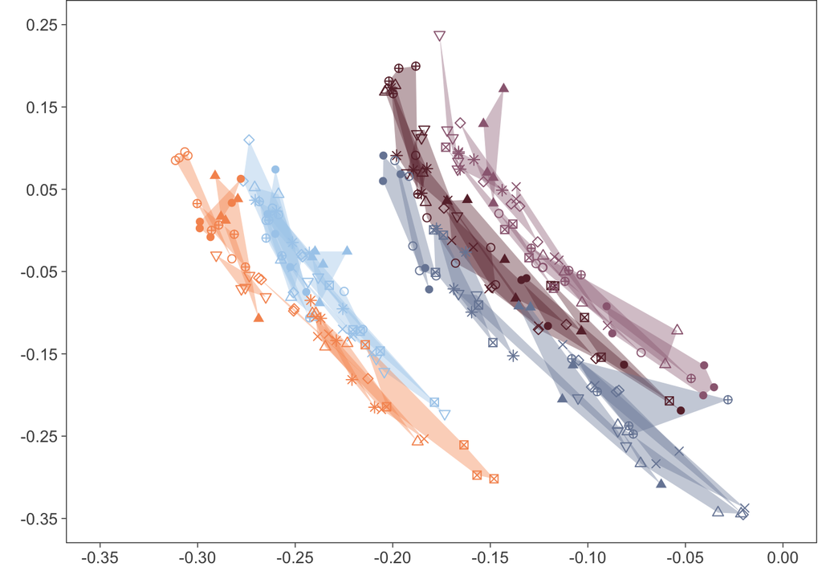

```r
# Convex hull polygons per group
hulls <- plyr::ddply(mds_spcc_grp, "unique_individuals", function(x){
  x[chull(x$X, x$Y), ]
})

# glimpse(hulls)

mds_spcc_grp %>%
  ggplot(aes(x = X, y = Y)) +
  geom_polygon(data = hulls, aes(x = X, y = Y, fill = unique_individuals), alpha = 0.4, linewidth = 0.2, show.legend = FALSE) +
  geom_point(aes(color = group_ID, shape = individual_ID), size = 2, stroke = 0.5) +
  scale_shape_manual(values = shps) +
  scale_color_manual(values = cols_grp) +
  scale_fill_manual(values = fills) +
  xlab("") + ylab("") +
  guides(color = guide_legend(title = "Group", override.aes = list(size = 3), order = 1), shape = guide_legend(title = "Individual", nrow = 1), fill = "none") +
  # Uncomment this line to turn off the legend
   guides(color = "none", shape = "none", fill = "none") +
  # Specify the x and y-axis limits so that these are the same across plots
  # Also make sure that each label retains two decimal places even when there is a trailing zero
  scale_x_continuous(limits = c(-0.35, 0), breaks = seq(-0.35, 0, 0.05), labels = sprintf("%.2f", round(seq(-0.35, 0, 0.05), 2))) +
  scale_y_continuous(limits = c(-0.35, 0.25), breaks = seq(-0.35, 0.25, 0.1), labels = sprintf("%.2f", round(seq(-0.35, 0.25, 0.1), 2))) +
  theme_bw() +
  theme(
    axis.title = element_text(size = 14),
    axis.text = element_text(size = 10),
    strip.text.x = element_text(size = 12),
    strip.text.y = element_text(size = 10),
    panel.grid.major = element_blank(),
    panel.grid.minor = element_blank(),
    axis.ticks = element_line(linewidth = 0.25),
    legend.position = "top",
    legend.key.spacing = unit(0.2, "lines"),
    # margin() arguments: top, right, bottom, left
    plot.margin = margin(0, 3, -3, -3, unit = "pt"),
    legend.margin = margin(2, -3, -5, -3, unit = "pt")
  )
```

```r
# Save this plot as an image file
# This image size (and font sizes or other aesthetics above) should be iteratively updated to fit a composite figure of multiple acoustic space plots created in other software
ggsave(filename = file.path(figures_path, "Fig_S2", "Suppl_AcousticSpace_SPCC_GroupMembership_IndividualPolygons.tiff"), width = 3.535, height = 3.771, units = "in", dpi = 300)
```

## Step 2: Individually distinctive dataset

Start with aesthetics.

```r
# Get colors for groups from the same palette used for spectrograms in lexicons
cols <- paletteer::paletteer_d("nationalparkcolors::Arches")
cols
```

```
## <colors>
## #A8CDECFF #F6955EFF #682C37FF #9B6981FF #7887A4FF #A89F8EFF
```

```r
# Combine MDS results from the SPCC and edit distance pipelines
mds_spcc_ind <- mds_coords %>%
  # Filter by the individual identity dataset calls and MDS coordinates from SPCC
  dplyr::filter(
    dataset == "Individual Identity", method == "SPCC"
  ) %>%
  # Convert strings to factors for plotting
  dplyr::mutate(
    group_ID = factor(group_ID),
    individual_ID = factor(individual_ID)
  )

glimpse(mds_spcc_ind)
```

```
## Rows: 250
## Columns: 8
## $ sound.files        <chr> "IndividualIdentity_Group1_Indiv1_Call1.wav", "Indi…
## $ X                  <dbl> 0.21374535, 0.26889058, 0.26140644, 0.23995884, 0.2…
## $ Y                  <dbl> -0.172620673, -0.060699604, -0.056085518, -0.101085…
## $ group_ID           <fct> 1, 1, 1, 1, 1, 1, 1, 1, 1, 1, 1, 1, 1, 1, 1, 1, 1, …
## $ individual_ID      <fct> 1, 1, 1, 1, 1, 10, 10, 10, 10, 10, 2, 2, 2, 2, 2, 3…
## $ dataset            <chr> "Individual Identity", "Individual Identity", "Indi…
## $ unique_individuals <chr> "1 - 1", "1 - 1", "1 - 1", "1 - 1", "1 - 1", "1 - 1…
## $ method             <chr> "SPCC", "SPCC", "SPCC", "SPCC", "SPCC", "SPCC", "SP…
```

```r
mds_edit_ind <- mds_coords %>%
  # Filter by the individual identity dataset calls and MDS coordinates from SPCC
  dplyr::filter(
    dataset == "Individual Identity", method == "edit"
  ) %>%
  dplyr::mutate(
    group_ID = factor(group_ID),
    individual_ID = factor(individual_ID)
  )

glimpse(mds_edit_ind)
```

```
## Rows: 250
## Columns: 8
## $ sound.files        <chr> "IndividualIdentity_Group1_Indiv1_Call1.wav", "Indi…
## $ X                  <dbl> 3.571417, 3.565482, 3.565496, 3.610579, 3.610555, 2…
## $ Y                  <dbl> -2.3770214, -0.9836958, -0.9838114, -1.1380147, -1.…
## $ group_ID           <fct> 1, 1, 1, 1, 1, 1, 1, 1, 1, 1, 1, 1, 1, 1, 1, 1, 1, …
## $ individual_ID      <fct> 1, 1, 1, 1, 1, 10, 10, 10, 10, 10, 2, 2, 2, 2, 2, 3…
## $ dataset            <chr> "Individual Identity", "Individual Identity", "Indi…
## $ unique_individuals <chr> "1 - 1", "1 - 1", "1 - 1", "1 - 1", "1 - 1", "1 - 1…
## $ method             <chr> "edit", "edit", "edit", "edit", "edit", "edit", "ed…
```

```r
levels(mds_spcc_ind$group_ID)
```

```
## [1] "1" "2" "3" "4" "5"
```

```r
levels(mds_spcc_ind$individual_ID)
```

```
##  [1] "1"  "2"  "3"  "4"  "5"  "6"  "7"  "8"  "9"  "10"
```

```r
# Colors by group (five)
cols_grp <- cols[1:length(levels(mds_spcc_ind$group))]
cols_grp
```

```
## <colors>
## #A8CDECFF #F6955EFF #682C37FF #9B6981FF #7887A4FF
```

```r
# Shapes by individual within groups
shps <- c(7, 8, 10, 4, 16, 17, 21, 23, 24, 6)
```

## Step 2a: Individual-level ploygons

### Edit distance, individually distinctive dataset and individual-level polygons

Edit distance first with a legend.

```r
hulls <- plyr::ddply(mds_edit_ind, "unique_individuals", function(x){
  x[chull(x$X, x$Y), ]
})

glimpse(hulls)
```

```
## Rows: 208
## Columns: 8
## $ sound.files        <chr> "IndividualIdentity_Group1_Indiv1_Call1.wav", "Indi…
## $ X                  <dbl> 3.571417, 3.565482, 3.610579, 2.592559, 2.755979, 2…
## $ Y                  <dbl> -2.3770214, -0.9836958, -1.1380147, -3.3250952, -1.…
## $ group_ID           <fct> 1, 1, 1, 1, 1, 1, 1, 1, 1, 1, 1, 1, 1, 1, 1, 1, 1, …
## $ individual_ID      <fct> 1, 1, 1, 10, 10, 10, 10, 2, 2, 2, 2, 3, 3, 3, 3, 3,…
## $ dataset            <chr> "Individual Identity", "Individual Identity", "Indi…
## $ unique_individuals <chr> "1 - 1", "1 - 1", "1 - 1", "1 - 10", "1 - 10", "1 -…
## $ method             <chr> "edit", "edit", "edit", "edit", "edit", "edit", "ed…
```

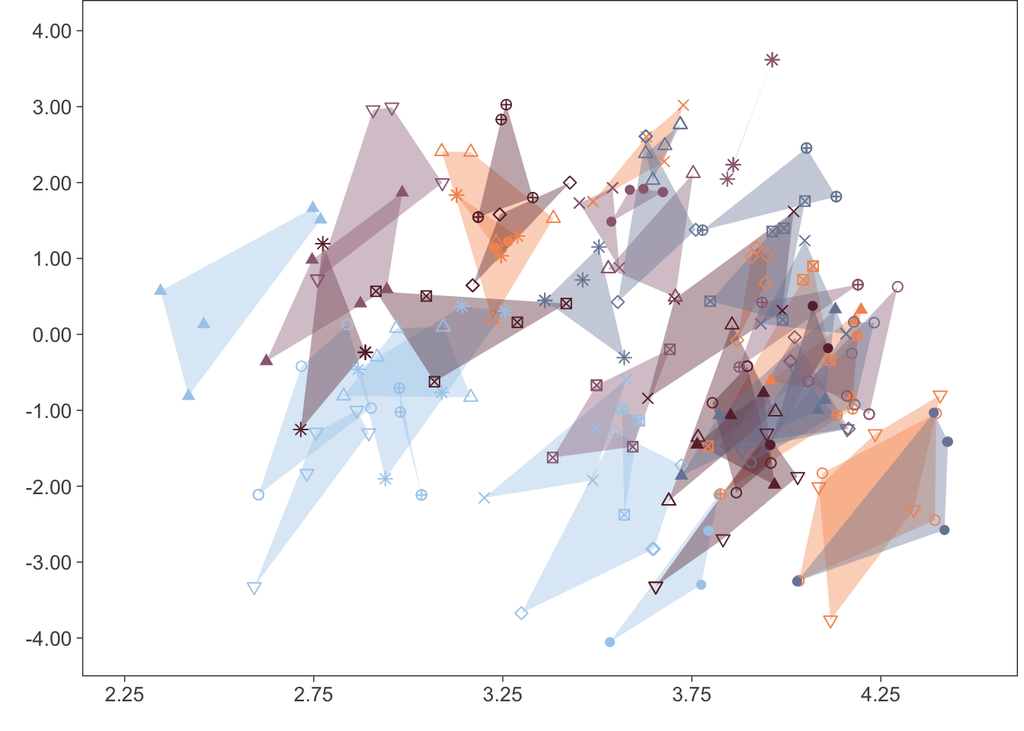

```r
mds_edit_ind %>%
  ggplot(aes(x = X, y = Y)) +
  geom_polygon(data = hulls, aes(x = X, y = Y, fill = unique_individuals), alpha = 0.4, linewidth = 0.2, show.legend = FALSE) +
  geom_point(aes(color = group_ID, shape = individual_ID), size = 2, stroke = 0.5) +
  scale_shape_manual(values = shps) +
  scale_color_manual(values = cols_grp) +
  scale_fill_manual(values = fills) +
  xlab("") + ylab("") +
  guides(color = guide_legend(title = "Group", override.aes = list(size = 3), order = 1), shape = guide_legend(title = "Individual", nrow = 1), fill = "none") +
   guides(color = "none", shape = "none", fill = "none") +
  # Specify the x and y-axis limits and breaks. Make sure that each label retains two decimal places even when there is a trailing zero
  scale_x_continuous(limits = c(2.25, 4.5), breaks = seq(2.25, 4.5, 0.5), labels = sprintf("%.2f", round(seq(2.25, 4.5, 0.5), 2))) +
  scale_y_continuous(limits = c(-4.1, 4), breaks = seq(-4, 4, 1), labels = sprintf("%.2f", round(seq(-4, 4, 1), 2))) +
  theme_bw() +
  theme(
    legend.position = "top",
    legend.key.spacing = unit(0.2, "line"),
    axis.title = element_text(size = 14),
    axis.text = element_text(size = 10),
    panel.grid.major = element_blank(),
    panel.grid.minor = element_blank(),
    axis.ticks = element_line(linewidth = 0.25),
    legend.title = element_text(size = 10),
    legend.text = element_text(size = 10),
    # margin() arguments: top, right, bottom, left
    plot.margin = margin(0, 3, -3, -3, unit = "pt"),
    legend.margin = margin(2, -3, -5, -3, unit = "pt")
  )
```

```r
# Save this plot as an image file
# This image size (and font sizes or other aesthetics above) should be iteratively updated to fit a composite figure of multiple acoustic space plots created in other software
ggsave(filename = file.path(figures_path, "Fig_S1", "Suppl_AcousticSpace_edit_IndividualIdentity_IndividualPolygons.tiff"), width = 3.535, height = 3.771, units = "in", dpi = 300)
```

### SPCC, individually distinctive dataset and individual-level polygons

SPCC next with a legend.

```r
hulls <- plyr::ddply(mds_spcc_ind, "unique_individuals", function(x){
  x[chull(x$X, x$Y), ]
})

glimpse(hulls)
```

```
## Rows: 211
## Columns: 8
## $ sound.files        <chr> "IndividualIdentity_Group1_Indiv1_Call1.wav", "Indi…
## $ X                  <dbl> 0.21374535, 0.23995884, 0.26140644, 0.26889058, 0.0…
## $ Y                  <dbl> -0.172620673, -0.101085969, -0.056085518, -0.060699…
## $ group_ID           <fct> 1, 1, 1, 1, 1, 1, 1, 1, 1, 1, 1, 1, 1, 1, 1, 1, 1, …
## $ individual_ID      <fct> 1, 1, 1, 1, 10, 10, 10, 10, 2, 2, 2, 2, 2, 3, 3, 3,…
## $ dataset            <chr> "Individual Identity", "Individual Identity", "Indi…
## $ unique_individuals <chr> "1 - 1", "1 - 1", "1 - 1", "1 - 1", "1 - 10", "1 - …
## $ method             <chr> "SPCC", "SPCC", "SPCC", "SPCC", "SPCC", "SPCC", "SP…
```

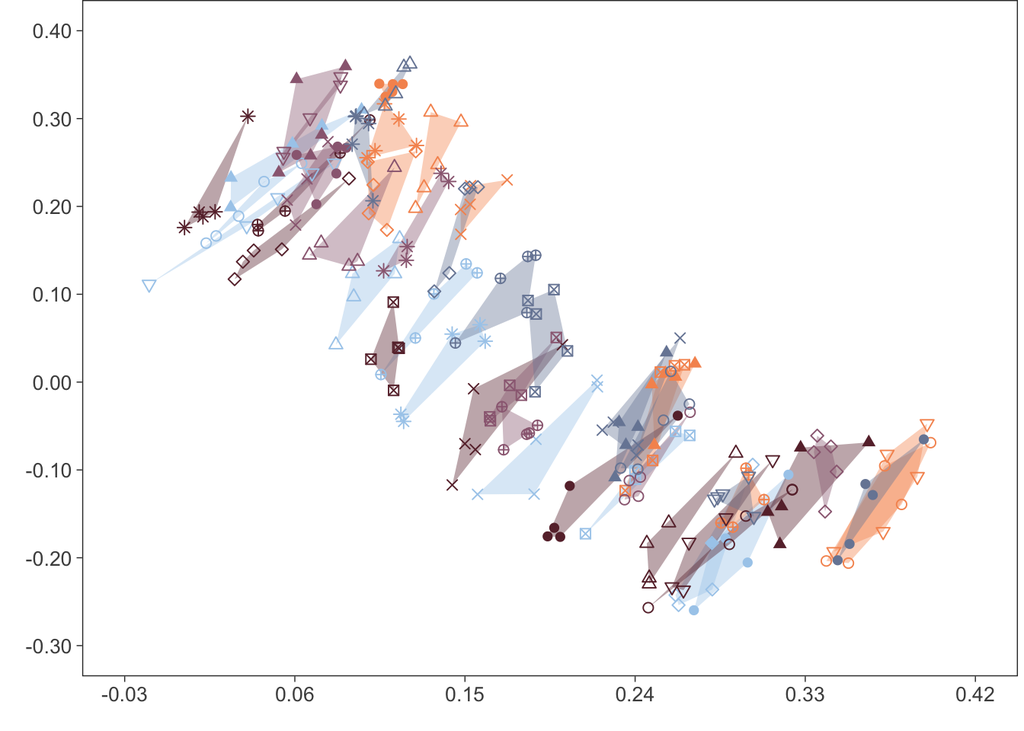

```r
mds_spcc_ind %>%
  ggplot(aes(x = X, y = Y)) +
  geom_polygon(data = hulls, aes(x = X, y = Y, fill = unique_individuals), alpha = 0.4, linewidth = 0.2, show.legend = FALSE) +
  geom_point(aes(color = group_ID, shape = individual_ID), size = 2, stroke = 0.5) +
  # facet_wrap(~ group_ID) +
  scale_shape_manual(values = shps) +
  scale_color_manual(values = cols_grp) +
  scale_fill_manual(values = fills) +
  xlab("") + ylab("") +
  guides(color = guide_legend(title = "Group", override.aes = list(size = 3), order = 1), shape = guide_legend(title = "Individual", nrow = 1), fill = "none") +
   guides(color = "none", shape = "none", fill = "none") +
  # Specify the x and y-axis limits and breaks. Make sure that each label retains two decimal places even when there is a trailing zero
  scale_x_continuous(limits = c(-0.03, 0.42), breaks = seq(-0.03, 0.44, 0.09), labels = sprintf("%.2f", round(seq(-0.03, 0.44, 0.09), 2))) +
  scale_y_continuous(limits = c(-0.3, 0.4), breaks = seq(-0.3, 0.4, 0.1), labels = sprintf("%.2f", round(seq(-0.3, 0.4, 0.1), 2))) +
  theme_bw() +
  theme(
    legend.position = "top",
    legend.key.spacing = unit(0.2, "line"),
    axis.title = element_text(size = 14),
    axis.text = element_text(size = 10),
    panel.grid.major = element_blank(),
    panel.grid.minor = element_blank(),
    axis.ticks = element_line(linewidth = 0.25),
    legend.title = element_text(size = 10),
    legend.text = element_text(size = 10),
    # margin() arguments: top, right, bottom, left
    plot.margin = margin(0, 3, -3, -3, unit = "pt"),
    legend.margin = margin(2, -3, -5, -3, unit = "pt")
  )
```

```r
# Save this plot as an image file
# This image size (and font sizes or other aesthetics above) should be iteratively updated to fit a composite figure of multiple acoustic space plots created in other software
ggsave(filename = file.path(figures_path, "Fig_S2", "Suppl_AcousticSpace_SPCC_IndividualIdentity_IndividualPolygons.tiff"), width = 3.535, height = 3.771, units = "in", dpi = 300)
```

## Step 2b: Group-level ploygons

### Edit distance, individual identity dataset and group-level polygons

Edit distance first with a legend. Use the same continuous x and y-axis scales as the main figures.

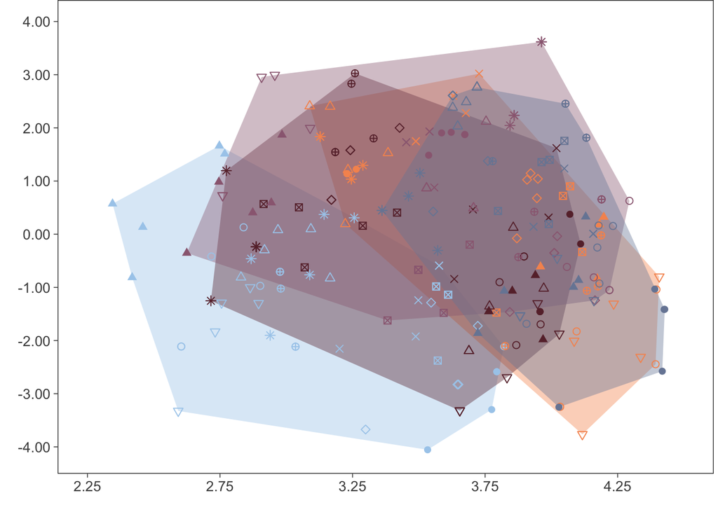

```r
# Convex hull polygons per group
hulls <- plyr::ddply(mds_edit_ind, "group_ID", function(x){
  x[chull(x$X, x$Y), ]
})

# glimpse(hulls)

mds_edit_ind %>%
  ggplot(aes(x = X, y = Y)) +
  geom_polygon(data = hulls, aes(x = X, y = Y, fill = group_ID), alpha = 0.4, linewidth = 0.2, show.legend = FALSE) +
  geom_point(aes(color = group_ID, shape = individual_ID), size = 2, stroke = 0.5) +
  scale_shape_manual(values = shps) +
  scale_color_manual(values = cols_grp) +
  scale_fill_manual(values = cols_grp) +
  xlab("") + ylab("") +
  guides(color = guide_legend(title = "Group", override.aes = list(size = 3), order = 1), shape = guide_legend(title = "Individual", nrow = 1), fill = "none") +
  # Uncomment this line to turn off the legend
   guides(color = "none", shape = "none", fill = "none") +
  # Specify the x and y-axis limits so that these are the same across plots
  # Also make sure that each label retains two decimal places even when there is a trailing zero
  scale_x_continuous(limits = c(2.25, 4.5), breaks = seq(2.25, 4.5, 0.5), labels = sprintf("%.2f", round(seq(2.25, 4.5, 0.5), 2))) +
  scale_y_continuous(limits = c(-4.1, 4), breaks = seq(-4, 4, 1), labels = sprintf("%.2f", round(seq(-4, 4, 1), 2))) +
  theme_bw() +
  theme(
    axis.title = element_text(size = 14),
    axis.text = element_text(size = 10),
    strip.text.x = element_text(size = 12),
    strip.text.y = element_text(size = 10),
    panel.grid.major = element_blank(),
    panel.grid.minor = element_blank(),
    axis.ticks = element_line(linewidth = 0.25),
    legend.position = "top",
    legend.key.spacing = unit(0.2, "lines"),
    # margin() arguments: top, right, bottom, left
    plot.margin = margin(0, 3, -3, -3, unit = "pt"),
    legend.margin = margin(2, -3, -5, -3, unit = "pt")
  )
```

```r
# Save this plot as an image file
# This image size (and font sizes or other aesthetics above) should be iteratively updated to fit a composite figure of multiple acoustic space plots created in other software
ggsave(filename = file.path(figures_path, "Fig_S1", "Suppl_AcousticSpace_edit_IndividualIdentity_GroupPolygons.tiff"), width = 3.535, height = 3.771, units = "in", dpi = 300)
```

### SPCC, individual identity dataset and group-level polygons

SPCC with a legend. Use the same continuous x and y-axis scales as the main figures.

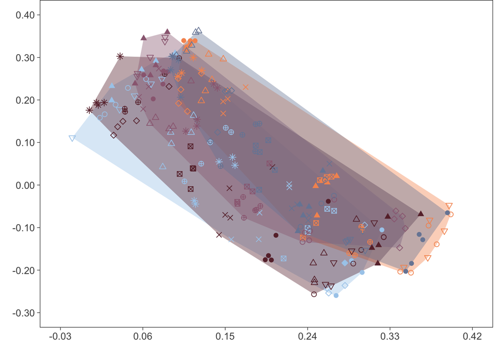

```r
# Convex hull polygons per group
hulls <- plyr::ddply(mds_spcc_ind, "group_ID", function(x){
  x[chull(x$X, x$Y), ]
})

# glimpse(hulls)

mds_spcc_ind %>%
  ggplot(aes(x = X, y = Y)) +
  geom_polygon(data = hulls, aes(x = X, y = Y, fill = group_ID), alpha = 0.4, linewidth = 0.2, show.legend = FALSE) +
  geom_point(aes(color = group_ID, shape = individual_ID), size = 2, stroke = 0.5) +
  scale_shape_manual(values = shps) +
  scale_color_manual(values = cols_grp) +
  scale_fill_manual(values = cols_grp) +
  xlab("") + ylab("") +
  guides(color = guide_legend(title = "Group", override.aes = list(size = 3), order = 1), shape = guide_legend(title = "Individual", nrow = 1), fill = "none") +
  # Uncomment this line to turn off the legend
   guides(color = "none", shape = "none", fill = "none") +
  # Specify the x and y-axis limits so that these are the same across plots
  # Also make sure that each label retains two decimal places even when there is a trailing zero
  scale_x_continuous(limits = c(-0.03, 0.42), breaks = seq(-0.03, 0.44, 0.09), labels = sprintf("%.2f", round(seq(-0.03, 0.44, 0.09), 2))) +
  scale_y_continuous(limits = c(-0.3, 0.4), breaks = seq(-0.3, 0.4, 0.1), labels = sprintf("%.2f", round(seq(-0.3, 0.4, 0.1), 2))) +
  theme_bw() +
  theme(
    axis.title = element_text(size = 14),
    axis.text = element_text(size = 10),
    strip.text.x = element_text(size = 12),
    strip.text.y = element_text(size = 10),
    panel.grid.major = element_blank(),
    panel.grid.minor = element_blank(),
    axis.ticks = element_line(linewidth = 0.25),
    legend.position = "top",
    legend.key.spacing = unit(0.2, "lines"),
    # margin() arguments: top, right, bottom, left
    plot.margin = margin(0, 3, -3, -3, unit = "pt"),
    legend.margin = margin(2, -3, -5, -3, unit = "pt")
  )
```

```r
# Save this plot as an image file
# This image size (and font sizes or other aesthetics above) should be iteratively updated to fit a composite figure of multiple acoustic space plots created in other software
ggsave(filename = file.path(figures_path, "Fig_S2", "Suppl_AcousticSpace_SPCC_IndividualIdentity_GroupPolygons.tiff"), width = 3.535, height = 3.771, units = "in", dpi = 300)
```